# MrOS_EDA

Kate Bowie

2024-09-23

## Purpose

The purpose of this .RMD is to examine how rarefying (or downsampling) can potentially affect results, measured with both alpha and beta diversity measures. The samples are 16S rRNA sequencing data from the MrOS cohort. The layout is investigating samples of varying read depths (>9000, 9000 < 10,000, and >50,000 reads) and comparing no-downsampling, downsampling to 1000, and downsampling to 9000 reads/sample. Part of downsampling is that all samples are surveyed randomly and ASVs are thrown out if they do not appear in many samples, so this is also something to keep in mind.

The idea thought is that there are a couple samples >50K reads, so is only sampling a small amount of reads an accurate representation of those samples? Expected: That the unrarefied will have the highest alpha diversity compared to 1000 and 9000 due to looking at the entirety of the sample as compared to a subset. This may only be visible in the observed. Will also be doing stacked barplots to check if there are any substantial differences between any of the downsampling.

# Set-up

```r
library(phyloseq)
library(ggplot2)
#library(decontam)
library(tidyverse)
library(patchwork)
library(kableExtra)
library(RColorBrewer)
library(speedyseq)
library(here)
library(microshades)
```

## Load-in data

```r
load(here("data", "Final_Analyses", "phyloseq.RData"))
```

What is all this stuff? * data - dataframe; rows = sequences; columns = samples? * meta - dataframe; metadata that should be worked with * meta_base - metadata for baseline collection * meta_S1 - metadata from visit 1 collections * meta_S2 - metadata from visit 2 collections * metadata - all metadata not transcribed * otus - dataframe that looks similar to data, but has 7 less samples..? * ps_base - ps object that’s been filtered for baseline visits The rest feels kind of self-explanatory.. (except for temp?)

After talking with Lisa, it seems that decontam just won’t work. Going to attempt visualizing data as is, without any decontam. Hopefully, since the urine was clean catch, there will be enough signal (find citation for clean catch vs cath urine collection in men).

Will be doing the EDA on “baseline”, because that includes all of the samples and no repeats from the sleep study visits (S1, S2).

# MetaData -

According to AUA (american urology assoc), scores for each symptom go from 0 –> 5; 0 = never, 5 = almost always

1. Over the past month, how often have you had the feeling of not completely emptying your bladder after you finished urinating? *PSEMPTY*
2. Over the past month, how often have you had to urinate again less than 2 hours after you finished urinating? *PSAGAIN*
3. Over the past month, how often have you found that you stopped and started again several times when you urinated? *PSSTOP*
4. Over the past month, how often have you found it hard to hold your urine? *PSPOST*
5. Over the past month, how often have you had a weak urine stream? *PSWEAK*
6. Over the past month, how often have you had to push or strain to begin urination? *PSPUSH*
7. Over the past month, have you had to get up to urinate during the night? Give a score to the number of times. *PSUP*

Found here: https://www.cigna.com/individuals-families/health-wellness/hw/medical-topics/american-urological-association-symptom-index-ug1952

# Luts breakdown

- LUTS: 1 - no LUTS, 2- Moderate LUTS 3- Severe LUTS
- PSSCORE: 0-7 = no/mild LUTS, 8-19 = moderate LUTS, >20 = severe LUTS

# Metadata

### getting rid of metadata

So I cannot run plot_bar in it’s current state, because it takes up too much memory. Now I have to play this fun game where I try to get rid of any extraneous information to preserve memory. I will also need to use tax_glom at the genus level.

```r
rm(list=setdiff(ls(), "ps_base"))
```

```r
meta_base <- data.frame(ps_base@sam_data)

meta_base <- meta_base %>% select(ID, Sample, sample_type, SITE, GIRACE, GIHISPA, marital_status, HWBMI.x, age, Race, Education, current_health, Diabetes, PSSCORE, LUTS, PSBPH, MHPC, PSEMPTY, PSAGAIN, PSSTOP, PSPOST, PSWEAK, PSPUSH, PSUP, PSQL, PSCONTRL, PSDRIP, PSPROBLM, MHPROST, GIRACE, SampleSums) %>%
  filter(!(is.na(LUTS))) %>% mutate(LUTS = as.factor(LUTS))

meta_base <- meta_base %>% mutate(LUTS_cat  = case_when(
  PSSCORE > 7 ~ "moderate/severe",
  PSSCORE <= 7 ~ "no/mild"
))

sample_data(ps_base) <- meta_base
```

Keeping only parts of the metadata I find useful: the clinical characteristics (ie answers to the 7 prostate symptom score), BPH history, PC history, current health, race, education, BMI, total reads for each sample, LUTS category, etc. Missing antiboitic usage, which is included in the analysis plan.

### updating sample sums

```r
min(sample_sums(ps_base))
```

```
## [1] 1018
```

```r
sample_data(ps_base)$SampleSums <- sample_sums(ps_base)

# updating the metabase, in the case that I want to use it for easier plotting later on
meta_base <- data.frame(ps_base@sam_data)
```

# Comparing LUTS

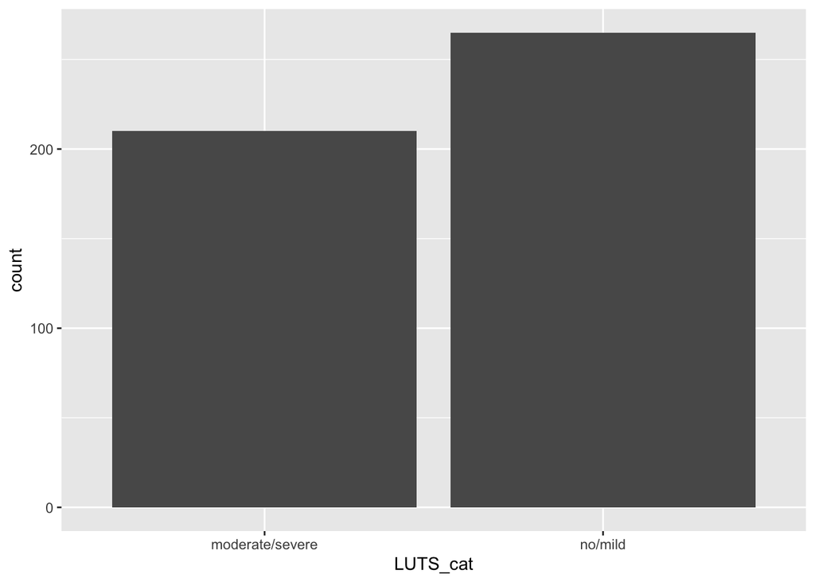

```r
ggplot(meta_base, aes(x = LUTS_cat)) + geom_bar()
```

So to be clear, there are two categories: LUTS and LUTS_cat.

This is because LUTS is the split into three categories, while we need two categories because the numbers for severe disease are so low. We have combined moderate and severe together, as well as no/mild LUTS. LUTS_cat is the useful term for our analyses.

# Fixing tax table

Many of the genera had underlines with numbers (ie Prevotella_6) which can be confusing in analyses. With Lisa’s guidance, I created a new tax table that combines all the genera together and takes off the numbers.

```r
ps_base_newtax <- ps_base #re-name variable

new_tax_table <- data.frame(ps_base_newtax@tax_table)

new_tax_table$Genus <- as.character(new_tax_table$Genus)
new_tax_table$Genus <- gsub('_[0-9]','',new_tax_table$Genus)
new_tax_table$Genus <- as.factor(new_tax_table$Genus)

tax_table(ps_base_newtax)<-as.matrix(new_tax_table)
```

# Glomerate at genus level

```r
ps_g <- tax_glom(ps_base_newtax, "Genus", NArm = FALSE)
```

# Kingdom - Stacked bar plot

Taking a look at ps_base

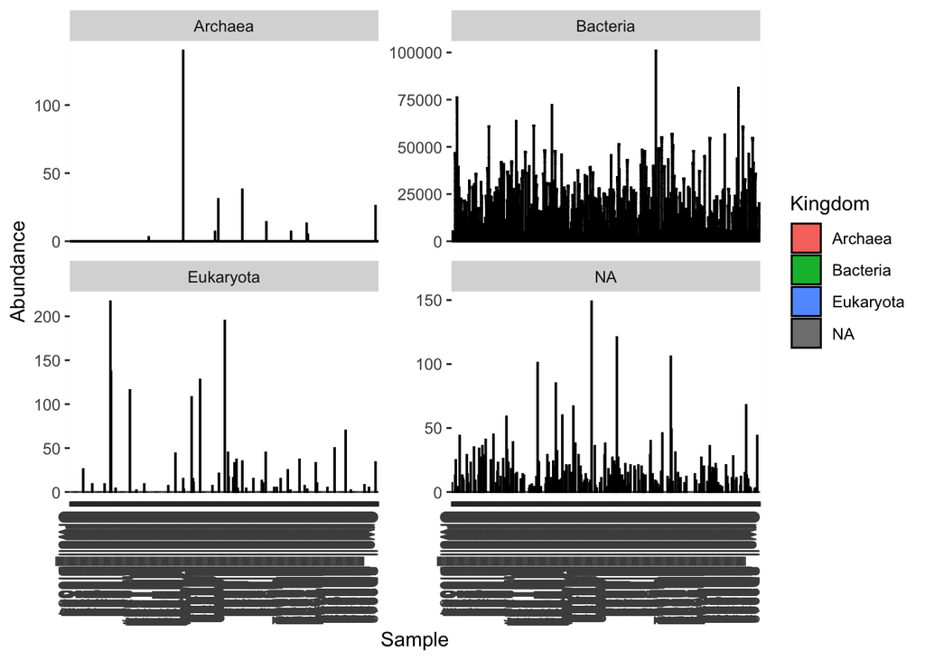

```r
plot_bar(ps_g, fill = "Kingdom") + facet_wrap(~Kingdom, scales = "free_y")
```

Looking at the reads for each of the four kingdoms. There are a decent amount of reads that map to Eukaryotes and need to be removed. There’s also a ton of NA reads that could be problematic.

### Removing eukaryotes

```r
ps_base_newtax <- subset_taxa(ps_base_newtax, Kingdom %in% c("Bacteria", "Archaea"))

ps_g <- tax_glom(ps_base_newtax, "Genus", NArm = FALSE)
```

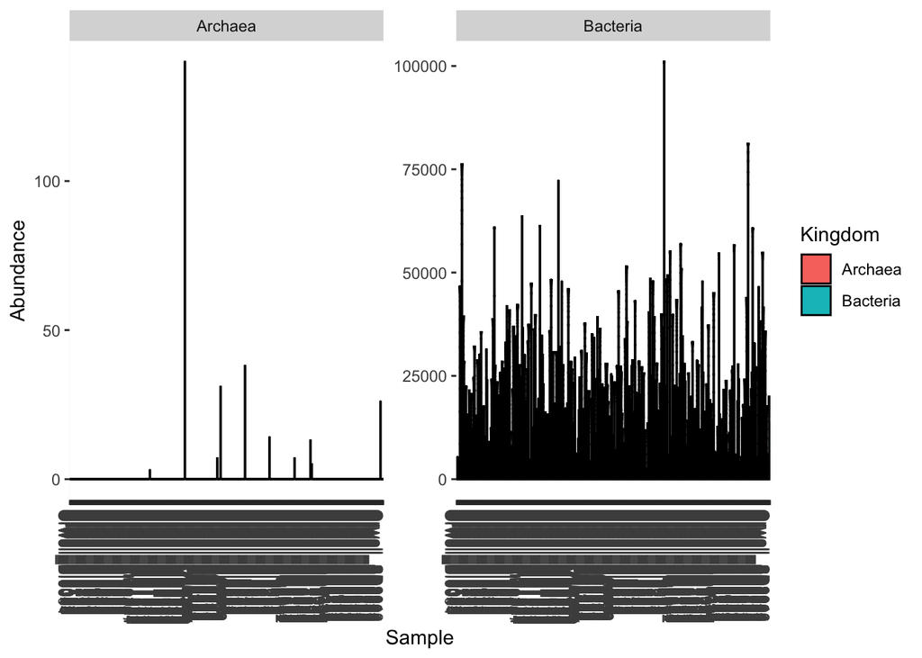

```r
plot_bar(ps_g, fill = "Kingdom") + facet_wrap(~Kingdom, scales = "free_y")
```

Replotting the Kingdom stacked bar plot after removal of reads mapping to Eukaryotes and NA. The overwhelming majority of sequencing reads map to Bacteria, while a few map to Archaea.

# Saving the objects

```r
save.image("ps_base.RData")
```

This will save a new .RData file with meta_base, the new_tax_table (without a ps object), ps_base (original with all eukaryotic reads and old tax table), ps_base_newtax (ps with updated tax_table but no eukaryotic reads), and ps_g, which is the object that will be used later.

Cleaning up a little

```r
rm(ps_base, new_tax_table)
```

# Histogram of reads

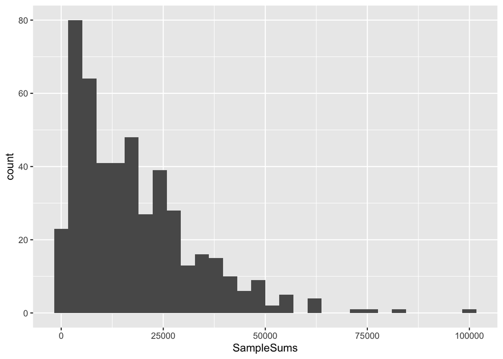

```r
ggplot(meta_base, aes(x = SampleSums)) + geom_histogram()
```

# Rarefying

Will be rarefying to the minimum sampling depth (1000 reads) because this allows us to examine all samples in this dataset.

```r
ps <- rarefy_even_depth(ps_g, sample.size = 1000, replace = FALSE, rngseed = 100)
```

```
## `set.seed(100)` was used to initialize repeatable random subsampling.
```

```
## Please record this for your records so others can reproduce.
```

```
## Try `set.seed(100); .Random.seed` for the full vector
```

```
## ...
```

```
## 104OTUs were removed because they are no longer
## present in any sample after random subsampling
```

```
## ...
```

```r
meta_ps <- data.frame(ps@sam_data)
```

# clean-up

```r
rm(list=ls()[! ls() %in% c("ps","meta_ps")])
```

```r
save.image(here("data", "ps_cleaned.RData"))
```